# First Latin LOPIT data for TTT study

This is code to help analyse the first LOPIT data from the TTT study. It consists of 20 TMT-labelled samples - one from each of the fractions from the LOPIT experiment. Each fraction/sample was then analysed on the mass spectrometer and the data contains the peptides detected in the experiment. The 20 fractions were broken into 2 x 11-plex experiments where the 11th plex was a control sample that could be used to normalise between the two experiments and make the fractions 1-10 comparable to fractions 11-20. Thanks to Tom and Rayner, input data is available at https://github.com/ComputationalProteomicsUnit/ThreeTs/tree/master/proteomics/dLOPIT/pilot/data.

We will start off by calling on libraries required for the analysis and setting up working directories….

```r
library(pRolocdata)
library(MSnbase)
library(gplots)
library(reshape2)
library(ggbiplot)
library(org.Hs.eg.db)
library("biomaRt")
library(goseq)
library(limma)
library(ggplot2)
library(RColorBrewer)
library(zoo)
#Setting working directories
wd = "/Users/manasa/Documents/Work/TTT/02_Proteomics/04_First-Latin-LOPIT/"
setwd(wd)
getwd()
```

```
[1] "/Users/manasa/Documents/Work/TTT/02_Proteomics/04_First-Latin-LOPIT"
```

```r
indir = paste(wd,"Input",sep="/")
outdir = paste(wd,paste(Sys.Date(),"Output",sep = "_"),sep = "/")
if (exists(outdir)){
  print("Outdir exists")
}else{
  dir.create(outdir)
}
```

Having established working directories, it is time to read in the data that is to be analysed. We will have peptide abundance values from the two 11-plex experiments, file(s) telling us which sample/fraction is which TMT tag as well as Katerina and Claire’s list of markers for various cellular components. In addition, we will still keep the contaminants file to remove known mass spectrometry contaminants.

Now that we have loaded all the packages we need for working with this data, let’s move on to the data.

```r
# -----------------------------------------------
# Step 01: Read data
# Read in all the data required for analysis
# -----------------------------------------------
# File of contaminants - proteins to exclude from analysis as are things like keratin, alcohol dehydrogenase etc....
contam = read.delim("Input/Common contaminant_all.csv",sep=",",header=T)
# Read in the data files that contain peptide level output from Proteome discoverer...
# Note: The columns that begin with "Found.in.Sample.in" correspond to various samples in the study.
# Columns of interest are "sequence", "modifications","master.protein.accessions","abundance","quan.info"
raw.data = read.table("Input/dLOPIT_22plex_PeptideGroups.txt",sep="\t",comment.char="",as.is=T,header=T)
head(raw.data)
```

|  | Checked | Confidence | Sequence | Modifications | Qvality.PEP | Qvality.q.value | Number.of.Protein.Groups | Number.of.Proteins | Number.of.PSMs | Master.Protein.Accessions | Number.of.Missed.Cleavages | Theo.MHplus.in.Da | Found.in.File.in.F3.dLOPIT_M1_F | Found.in.File.in.F4.dLOPIT_M2_F | Found.in.Sample.in.S34.F4.126.Sample | Found.in.Sample.in.S35.F4.127N.Sample | Found.in.Sample.in.S36.F4.127C.Sample | Found.in.Sample.in.S37.F4.128N.Sample | Found.in.Sample.in.S38.F4.128C.Sample | Found.in.Sample.in.S39.F4.129N.Sample | Found.in.Sample.in.S40.F4.129C.Sample | Found.in.Sample.in.S41.F4.130N.Sample | Found.in.Sample.in.S42.F4.130C.Sample | Found.in.Sample.in.S43.F4.131N.Sample | Found.in.Sample.in.S44.F4.131C.Sample | Found.in.Sample.in.S23.F3.126.Sample | Found.in.Sample.in.S24.F3.127N.Sample | Found.in.Sample.in.S25.F3.127C.Sample | Found.in.Sample.in.S26.F3.128N.Sample | … |
| --- | --- | --- | --- | --- | --- | --- | --- | --- | --- | --- | --- | --- | --- | --- | --- | --- | --- | --- | --- | --- | --- | --- | --- | --- | --- | --- | --- | --- | --- | --- |
| 1 | False | High | RLPEYPQVDDLLLRR | 1xTMT6plex [N-Term] | 7.49792e-05 | 0 | 2 | 5 | 1 | E7ERK9; A0A087WTA5 | 2 | 2112.213 | Not Found | High | High | High | High | High | High | High | High | High | High | High | High | Not Found | Not Found | Not Found | Not Found | … |
| 2 | False | High | SSDASTAQPPESQPLPASQTPASNQPK | 2xTMT6plex [N-Term; K27] | 2.19304e-05 | 0 | 1 | 1 | 2 | P48634 | 0 | 3179.622 | High | High | High | High | High | High | High | High | High | High | High | High | High | High | High | High | High | … |
| 3 | False | High | IEDVGSDEEDDSGKDK | 3xTMT6plex [N-Term; K14; K16] | 5.79633e-05 | 0 | 1 | 2 | 2 | P08238 | 1 | 2425.219 | High | High | High | High | High | High | High | High | High | High | High | High | High | Not Found | Not Found | Not Found | High | … |
| 4 | False | High | LSSSDAPAQDTGSSAAAVETDASR | 1xTMT6plex [N-Term] | 1.78805e-05 | 0 | 1 | 4 | 2 | Q7Z4S6 | 0 | 2523.201 | High | High | High | High | High | High | High | High | High | High | High | High | High | Not Found | Not Found | Not Found | High | … |
| 5 | False | High | DVASTAGEEGDTSLRESLHPVTR | 1xTMT6plex [N-Term] | 5.01618e-05 | 0 | 1 | 2 | 1 | Q8ND24 | 1 | 2656.338 | Not Found | High | High | High | High | High | High | High | Not Found | High | High | High | High | Not Found | Not Found | Not Found | Not Found | … |
| 6 | False | High | NPQSTEPVLGGGEPPFHGHR | 1xTMT6plex [N-Term] | 6.51869e-05 | 0 | 1 | 2 | 1 | Q9BXW7 | 0 | 2342.184 | High | Not Found | Not Found | Not Found | Not Found | Not Found | Not Found | Not Found | Not Found | Not Found | Not Found | Not Found | Not Found | Not Found | Not Found | Not Found | High | … |

```r
dim(raw.data)
```

```
[1] 50140    89
```

```r
# Create a sample data file based on input
samp.names = grep("Abundance",colnames(raw.data),value=T)
samp.dat = as.data.frame(cbind(samp.names,sapply(strsplit(samp.names,"\\."),"[[",3),sapply(strsplit(samp.names,"\\."),"[[",2)))
rownames(samp.dat) = samp.dat$samp.names
colnames(samp.dat)[2:3] = c("TMT","Exp")
samp.dat$Rep = rep(c(2,1),each=11)
samp.dat$Order = c(seq(12,22),seq(1,11))
samp.dat = samp.dat[order(samp.dat$Order),]
# Read in the file containing Claire and Katerina's classifications
cell.markers = read.delim("Input/markers_claire_kat.tsv",sep="\t",header=F,stringsAsFactors = F)
colnames(cell.markers) = c("Protein","Location")
rownames(cell.markers) = cell.markers$Protein
cell.markers = cell.markers[,2:1]
```

Data has 89 columns and 50140 rows - each row belonging to a peptide abundance value across one or more of 22 samples. We now go through a series of filtering steps to obtain a dataset we can use for downstream analyses.

```r
# ---------------------------------------------------------------------------------
# Step 02 : Filter
# We perform 2 layers of filtering - for unique proteins, to remove contaminants
# ---------------------------------------------------------------------------------
# Filter 1a : Filter only for those peptides that have a unique master protein. Done using column "quan.info" and titled 'Unique'
peptide.stats = table(raw.data$Quan.Info)
peptide.stats
```

```
NoQuanValues    NotUnique       Unique
        1292         2801        46047
```

```r
filt.1a = raw.data[which(raw.data$Quan.Info == "Unique"),]
dim(filt.1a) # 46047 are unique peptides, 2801 are non-unique and 1292 are missing values
```

```
[1] 46047    89
```

```r
# Filter 1b : Filter out those proteins that are contaminants from the contaminants list and annotate missing values
filt.1b = filt.1a[-which(filt.1a$Master.Protein.Accessions %in% contam$Protein.Group.Accessions),]
num.contams = length(which(filt.1a$Master.Protein.Accessions %in% contam$Protein.Group.Accessions))
dim(filt.1b) # 45694 filtered proteins
```

```
[1] 45694    89
```

```r
print(num.contams) # 353 contaminant proteins
```

```
[1] 353
```

```r
# Adding extra information about rows with missing values
filt.1b$count.missing = rowSums(is.na(filt.1b[,c(59:68,70:79)]))
filt.1b$missing.1.to.10 = rowSums(is.na(filt.1b[,c(59:68)]))
filt.1b$missing.12.to.21 = rowSums(is.na(filt.1b[,c(70:79)]))
# Indicating which rows contain missing values
filt.1b$Missing = FALSE
filt.1b$Missing[which(filt.1b$count.missing > 0)] = TRUE
# Some data stats
head(filt.1b)
```

|  | Checked | Confidence | Sequence | Modifications | Qvality.PEP | Qvality.q.value | Number.of.Protein.Groups | Number.of.Proteins | Number.of.PSMs | Master.Protein.Accessions | Number.of.Missed.Cleavages | Theo.MHplus.in.Da | Found.in.File.in.F3.dLOPIT_M1_F | Found.in.File.in.F4.dLOPIT_M2_F | Found.in.Sample.in.S34.F4.126.Sample | Found.in.Sample.in.S35.F4.127N.Sample | Found.in.Sample.in.S36.F4.127C.Sample | Found.in.Sample.in.S37.F4.128N.Sample | Found.in.Sample.in.S38.F4.128C.Sample | Found.in.Sample.in.S39.F4.129N.Sample | Found.in.Sample.in.S40.F4.129C.Sample | Found.in.Sample.in.S41.F4.130N.Sample | Found.in.Sample.in.S42.F4.130C.Sample | Found.in.Sample.in.S43.F4.131N.Sample | Found.in.Sample.in.S44.F4.131C.Sample | Found.in.Sample.in.S23.F3.126.Sample | Found.in.Sample.in.S24.F3.127N.Sample | Found.in.Sample.in.S25.F3.127C.Sample | Found.in.Sample.in.S26.F3.128N.Sample | … |
| --- | --- | --- | --- | --- | --- | --- | --- | --- | --- | --- | --- | --- | --- | --- | --- | --- | --- | --- | --- | --- | --- | --- | --- | --- | --- | --- | --- | --- | --- | --- |
| 2 | False | High | SSDASTAQPPESQPLPASQTPASNQPK | 2xTMT6plex [N-Term; K27] | 2.19304e-05 | 0 | 1 | 1 | 2 | P48634 | 0 | 3179.622 | High | High | High | High | High | High | High | High | High | High | High | High | High | High | High | High | High | … |
| 3 | False | High | IEDVGSDEEDDSGKDK | 3xTMT6plex [N-Term; K14; K16] | 5.79633e-05 | 0 | 1 | 2 | 2 | P08238 | 1 | 2425.219 | High | High | High | High | High | High | High | High | High | High | High | High | High | Not Found | Not Found | Not Found | High | … |
| 4 | False | High | LSSSDAPAQDTGSSAAAVETDASR | 1xTMT6plex [N-Term] | 1.78805e-05 | 0 | 1 | 4 | 2 | Q7Z4S6 | 0 | 2523.201 | High | High | High | High | High | High | High | High | High | High | High | High | High | Not Found | Not Found | Not Found | High | … |
| 5 | False | High | DVASTAGEEGDTSLRESLHPVTR | 1xTMT6plex [N-Term] | 5.01618e-05 | 0 | 1 | 2 | 1 | Q8ND24 | 1 | 2656.338 | Not Found | High | High | High | High | High | High | High | Not Found | High | High | High | High | Not Found | Not Found | Not Found | Not Found | … |
| 6 | False | High | NPQSTEPVLGGGEPPFHGHR | 1xTMT6plex [N-Term] | 6.51869e-05 | 0 | 1 | 2 | 1 | Q9BXW7 | 0 | 2342.184 | High | Not Found | Not Found | Not Found | Not Found | Not Found | Not Found | Not Found | Not Found | Not Found | Not Found | Not Found | Not Found | Not Found | Not Found | Not Found | High | … |
| 7 | False | High | TSAALSTVGSAISR | 1xTMT6plex [N-Term] | 1.45691e-05 | 0 | 1 | 2 | 2 | O43399 | 0 | 1549.875 | High | High | High | High | High | High | High | High | High | High | High | High | High | Not Found | Not Found | Not Found | High | … |

```r
table(filt.1b$count.missing)
```

```
    0     1     2     3     4     5     6     7     8     9    10    11    12    13    14    15    16    17    18    19    20
 4731  2058  1651  2116  1099   491   343   291   240   190 20220  3472  2283  2759  1349   720   568   379   373   287    74
```

```r
table(filt.1b$missing.1.to.10) # 11794 peptides missing abundances in the first set of fractions
```

```
    0     1     2     3     4     5     6     7     8     9    10
28566  2355   916   569   429   306   265   172   173   149 11794
```

```r
table(filt.1b$missing.12.to.21) # 20458 peptides missing abundances in the second set of fractions
```

```
    0     1     2     3     4     5     6     7     8     9    10
 8391  3912  3313  4620  2153   899   653   498   458   339 20458
```

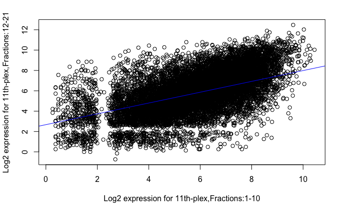

```r
# Looking at missing values using the 11th plex in both TMT experiments which is meant to normalise
plot(log2(filt.1b[,69]),log2(filt.1b[,80]),xlab="Log2 expression for 11th-plex,Fractions:1-10",ylab="Log2 expression for 11th-plex,Fractions:12-21")
abline(lm(log2(filt.1b[,69]) ~ log2(filt.1b[,80])), col="blue",pch=3)
```

```r
# Checking how many unique proteins intersect with the cellular markers provided by C&K
intersect(unique(filt.1b$Master.Protein.Accessions),cell.markers$Protein) # 691
```

```
  [1] "Q8NHP8" "Q9UIW2" "Q14573" "P25789" "P35221" "P34932" "P28074" "Q9NYH9" "O95202" "Q92896" "P53985" "P22570" "P46013" "Q8NCL4" "Q5JRX3" "P00558" "Q9NVP1"
 [18] "P05023" "Q9Y2X3" "Q01650" "Q96J84" "O00116" "Q8NBS9" "P49593" "Q10713" "P62277" "P13667" "Q86SF2" "P04843" "P39023" "P30101" "P07195" "Q96S52" "P55809"
 [35] "P06576" "P09661" "Q9UQE7" "P35222" "P07237" "Q969V3" "P18084" "Q969G3" "P08754" "P13674" "P62917" "P23368" "O14514" "O00567" "P17174" "P31040" "Q8TC12"
 [52] "Q04446" "P21399" "P16615" "O43242" "O95239" "P20020" "Q9Y2B0" "P05106" "P49588" "Q96G01" "O43765" "Q86UP2" "P00492" "Q9UNM6" "P22033" "P32322" "Q02543"
 [69] "P09543" "P48735" "Q9UGP8" "P35754" "O95881" "P62191" "P36383" "P46777" "P05556" "P17301" "Q12996" "P28838" "Q7RTV0" "Q5JRA6" "P17096" "P13489" "O00461"
 [86] "Q6P1M0" "Q9UHL4" "P13073" "P49589" "Q99808" "Q14699" "P04181" "Q10469" "P30405" "P05388" "Q8WTS6" "Q13423" "Q9NRX4" "P36957" "O96008" "P28062" "Q9Y4L1"
[103] "P27635" "P40939" "O95602" "P27824" "P36551" "P42285" "O76031" "P07858" "O14497" "O15371" "O60341" "Q9BT09" "P63092" "P23634" "P50454" "P54687" "Q12931"
[120] "O60513" "O75477" "P28331" "P49821" "P28288" "P12277" "P30740" "Q9BVJ6" "Q15293" "Q9UIG0" "Q9Y6I4" "P16219" "P09110" "Q8NBJ4" "Q5UIP0" "Q8N6G5" "Q92692"
[137] "Q8IY81" "P13804" "O75380" "P61353" "Q12972" "Q4G0N4" "P25705" "O00264" "P49454" "P62424" "Q9P0J1" "P49721" "O00400" "P15880" "Q5JTZ9" "P54819" "Q9H773"
[154] "P0C0S5" "P08865" "Q5SSJ5" "Q9NUJ1" "Q93008" "P35998" "P31930" "P42765" "P30530" "Q10471" "O94826" "Q9P0I2" "Q9BYC5" "P51572" "P30038" "Q3ZCQ8" "P31153"
[171] "P63220" "P07199" "O15460" "Q16698" "P19367" "P51659" "P00505" "P48449" "Q6NUK1" "P84095" "P40925" "P62266" "P22695" "P68431" "O00330" "Q8IYL3" "P24752"
[188] "Q14690" "P11388" "P62701" "P51570" "O14773" "O75879" "P28066" "P78316" "Q9GZY6" "P18754" "Q13151" "P31937" "Q9NR30" "P23229" "O00487" "O60264" "P53597"
[205] "P52888" "P23284" "P61247" "Q8NBJ5" "P05026" "P50895" "P08240" "Q14376" "Q9Y3U8" "Q96DZ1" "Q13200" "O00161" "P32004" "Q9BQ39" "P51798" "A6NHR9" "P62195"
[222] "P05091" "P11177" "O00231" "O15382" "Q9P121" "P62805" "P83731" "P18124" "Q71DI3" "P09622" "P62750" "Q99613" "Q9Y5M8" "O15254" "Q96JJ7" "P49411" "O75663"
[239] "P55036" "Q9H0A0" "Q13630" "P62263" "Q13948" "P16435" "P30084" "O43615" "P25398" "P36871" "P08648" "Q9BS26" "Q8TBA6" "Q16822" "O95470" "Q9BWD1" "P36578"
```

[output cut: 26 more lines]

```r
which(filt.1b$count.missing == 20)
```

```
 [1]   328  1575  2067  4993  7112  8095  8122  9274  9941 10004 11031 11578 11805 13379 13388 14525 14913 15066 20774 21358 21454 22935 23527 23868 23998 25037
[27] 25272 25500 25578 25694 26754 26992 27462 27641 27675 29864 29887 29890 30334 30720 30825 31958 32656 32945 33031 33443 33655 33848 33902 33943 34205 35974
[53] 36148 36737 37221 37826 37887 38015 39285 39336 40179 40555 41825 42634 43359 43579 44002 44152 44668 44738 44761 45266 45482 45621
```

```r
# Final level of filtering is removing rows for which there is no value in any of the fractions
filt.1c = filt.1b[-which(filt.1b$count.missing == 20),] # 45620 93
intersect(unique(filt.1c$Master.Protein.Accessions),cell.markers$Protein) #691
```

```
  [1] "Q8NHP8" "Q9UIW2" "Q14573" "P25789" "P35221" "P34932" "P28074" "Q9NYH9" "O95202" "Q92896" "P53985" "P22570" "P46013" "Q8NCL4" "Q5JRX3" "P00558" "Q9NVP1"
 [18] "P05023" "Q9Y2X3" "Q01650" "Q96J84" "O00116" "Q8NBS9" "P49593" "Q10713" "P62277" "P13667" "Q86SF2" "P04843" "P39023" "P30101" "P07195" "Q96S52" "P55809"
 [35] "P06576" "P09661" "Q9UQE7" "P35222" "P07237" "Q969V3" "P18084" "Q969G3" "P08754" "P13674" "P62917" "P23368" "O14514" "O00567" "P17174" "P31040" "Q8TC12"
 [52] "Q04446" "P21399" "P16615" "O43242" "O95239" "P20020" "Q9Y2B0" "P05106" "P49588" "Q96G01" "O43765" "Q86UP2" "P00492" "Q9UNM6" "P22033" "P32322" "Q02543"
 [69] "P09543" "P48735" "Q9UGP8" "P35754" "O95881" "P62191" "P36383" "P46777" "P05556" "P17301" "Q12996" "P28838" "Q7RTV0" "Q5JRA6" "P17096" "P13489" "O00461"
 [86] "Q6P1M0" "Q9UHL4" "P13073" "P49589" "Q99808" "Q14699" "P04181" "Q10469" "P30405" "P05388" "Q8WTS6" "Q13423" "Q9NRX4" "P36957" "O96008" "P28062" "Q9Y4L1"
[103] "P27635" "P40939" "O95602" "P27824" "P36551" "P42285" "O76031" "P07858" "O14497" "O15371" "O60341" "Q9BT09" "P63092" "P23634" "P50454" "P54687" "Q12931"
[120] "O60513" "O75477" "P28331" "P49821" "P28288" "P12277" "P30740" "Q9BVJ6" "Q15293" "Q9UIG0" "Q9Y6I4" "P16219" "P09110" "Q8NBJ4" "Q5UIP0" "Q8N6G5" "Q92692"
[137] "Q8IY81" "P13804" "O75380" "P61353" "Q12972" "Q4G0N4" "P25705" "O00264" "P49454" "P62424" "Q9P0J1" "P49721" "O00400" "P15880" "Q5JTZ9" "P54819" "Q9H773"
[154] "P0C0S5" "P08865" "Q5SSJ5" "Q9NUJ1" "Q93008" "P35998" "P31930" "P42765" "P30530" "Q10471" "O94826" "Q9P0I2" "Q9BYC5" "P51572" "P30038" "Q3ZCQ8" "P31153"
[171] "P63220" "P07199" "O15460" "Q16698" "P19367" "P51659" "P00505" "P48449" "Q6NUK1" "P84095" "P40925" "P62266" "P22695" "P68431" "O00330" "Q8IYL3" "P24752"
[188] "Q14690" "P11388" "P62701" "P51570" "O14773" "O75879" "P28066" "P78316" "Q9GZY6" "P18754" "Q13151" "P31937" "Q9NR30" "P23229" "O00487" "O60264" "P53597"
[205] "P52888" "P23284" "P61247" "Q8NBJ5" "P05026" "P50895" "P08240" "Q14376" "Q9Y3U8" "Q96DZ1" "Q13200" "O00161" "P32004" "Q9BQ39" "P51798" "A6NHR9" "P62195"
[222] "P05091" "P11177" "O00231" "O15382" "Q9P121" "P62805" "P83731" "P18124" "Q71DI3" "P09622" "P62750" "Q99613" "Q9Y5M8" "O15254" "Q96JJ7" "P49411" "O75663"
[239] "P55036" "Q9H0A0" "Q13630" "P62263" "Q13948" "P16435" "P30084" "O43615" "P25398" "P36871" "P08648" "Q9BS26" "Q8TBA6" "Q16822" "O95470" "Q9BWD1" "P36578"
```

[output cut: 26 more lines]

This isn’t unexpected because the 20 fractions are across the elution through the liquid chromatography column. Fractions 1-3 will have barely any proteins and the detections will usually start around fraction 4. Additionally, fractions 1-10 capture proteins from one set of cellular components while 12-21 from a different set of cellular components.

Therefore, I have made two additional missing count columns…..Missing.1.to.10 and Missing.12.to.21. Given the two sets of fractions represent two separate sets of cellular components, we would loose a lot of information if we only kept the overlapping set.

I also plotted the 11th-plex for both TMT experiments against each other. As you can see in the plot, there are clouds of points with low or no expression in one of the TMT-experiments. For the others, the second set of fractions (12-21) has higher values than the first set of fractions

```r
# -----------------------------------------------------------------------------------------
# Step 03 : Creating an MSnSet which is needed for using the MSnbase/pRolocdata packages
# -----------------------------------------------------------------------------------------
# Create an MSnSet object with all samples
# Subsetting data and metadata instances
all.data = as.matrix(filt.1c[,c(70:80,59:69)])
colnames(all.data) = samp.dat$Name
data.no.lysate = as.matrix(filt.1c[,c(70:79,59:68)])
colnames(data.no.lysate) = samp.dat$Name[c(1:10,12:21)]
# Peptide information
metadata = filt.1c[,c(10,1:9,81,90:93)]
# Sample information
rownames(samp.dat) = samp.dat$Name
# Creating MSnSet instances
res.all <- MSnSet(exprs = all.data,fData=metadata,pData = samp.dat)
# Samples minus the cell lysates (131C_1 and 131C_2)
res <- MSnSet(exprs=data.no.lysate,fData=metadata,pData = samp.dat[c(1:10,12:21),])
print(res)
```

```
MSnSet (storageMode: lockedEnvironment)
assayData: 45620 features, 20 samples
  element names: exprs
protocolData: none
phenoData
  sampleNames: 126.1 127N.1 ... 131N.2 (20 total)
  varLabels: samp.names TMT ... Name (6 total)
  varMetadata: labelDescription
featureData
  featureNames: 2 3 ... 50140 (45620 total)
  fvarLabels: Master.Protein.Accessions Checked ... Missing (15 total)
  fvarMetadata: labelDescription
experimentData: use 'experimentData(object)'
Annotation:
- - - Processing information - - -
 MSnbase version: 2.0.2
```

```r
# Normalise 'res' using the cell-lysate columns
first.norm = filt.1c[,c(70:79)]/filt.1c[,80]
sec.norm = filt.1c[,c(59:68)]/filt.1c[,69]
norm.dat = as.matrix(cbind(first.norm,sec.norm))
colnames(norm.dat) = samp.dat$Name[c(1:10,12:21)]
res.norm <- MSnSet(exprs = norm.dat,fData = metadata,pData = samp.dat[c(1:10,12:21),])
# Create two separate MSnSets for each 10-plex
set1 <- MSnSet(exprs = data.no.lysate[,1:10],fData=metadata,pData = samp.dat[1:10,])
set2 <- MSnSet(exprs = data.no.lysate[,11:20],fData=metadata,pData = samp.dat[12:21,])
# How many missing values per peptide
table(fData(res)$count.missing)
```

```
    0     1     2     3     4     5     6     7     8     9    10    11    12    13    14    15    16    17    18    19
 4731  2058  1651  2116  1099   491   343   291   240   190 20220  3472  2283  2759  1349   720   568   379   373   287
```

```r
colSums(is.na(exprs(res)))
```

```
 126.1 127N.1 127C.1 128N.1 128C.1 129N.1 129C.1 130N.1 130C.1 131N.1  126.2 127N.2 127C.2 128N.2 128C.2 129N.2 129C.2 130N.2 130C.2 131N.2
 36020  32519  31333  21584  22052  25485  21888  22759  20816  21008  14522  13951  12785  12595  12352  13049  12831  12993  13617  13164
```

```r
table(rowSums(is.na(exprs(res))))
```

```
    0     1     2     3     4     5     6     7     8     9    10    11    12    13    14    15    16    17    18    19
 4731  2058  1651  2116  1099   491   343   291   240   190 20220  3472  2283  2759  1349   720   568   379   373   287
```

I have created one master MSnSet containing all 22 plexes/fractions/samples. However, I have made separate ones for each experiment as it might be hard to compare them otherwise and we would loose a lot of data as discussed in the previous section. The only downside is whether or not we will be able to pick up proteins based on their profiles if they are missing in one set of fractions and not the other.

Looking at the numbers of missing values, there are several rows (20220) which are missing 10 fractions which is indicative of the fact that they only worked in one of the two 10-plexes. This isn’t unexpected because we expect the various cellular components to separate along the fractions.

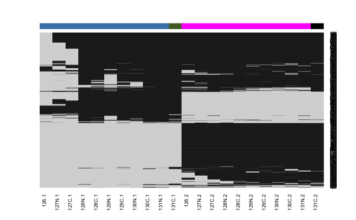

```r
# ---------------------------------------------------------------------------------
# Step 04 : Looking at missing values and assessing if we can impute them
# ---------------------------------------------------------------------------------
# Subsetting only those peptides with one or more missing values
# Replacing missing values with 0 and non-missing with 1
# Displaying a subset of missing values (1000-2000) as R crashes if I attempt to draw all 40,000
miss.many = res.all[rowSums(is.na(exprs(res.all)))>=1,]
exprs(miss.many)[exprs(miss.many) != 0] = 1
exprs(miss.many)[is.na(exprs(miss.many))] = 0
heatmap.2(exprs(miss.many)[1000:2000,], col = c("lightgray", "black"),scale = "none", dendrogram = "none",trace = "none", keysize = 0.5, key = FALSE,Colv=F,ColSideColors = rep(c("steelblue", "darkolivegreen","magenta","black"), times = c(10,1,10,1)))
```

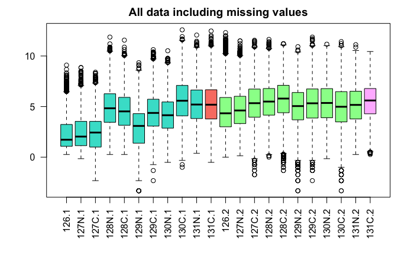

```r
# Impute missing valuesto the minimum value in the dataset as otherwise plots etc...fail
impute.res.all <- impute(res.all,method = "min")
impute.res <- impute(res,method = "min")
impute.res.norm <- impute(res.norm,method = "min")
impute.set1 <- impute(set1,method="min")
impute.set2 <- impute(set2,method="min")
# Melt expression values
res.miss = melt(exprs(res.all))
colnames(res.miss) = c("Row","Dosage","Abundance_imp")
# Draw boxplots of the data
boxplot(log2(res.miss$Abundance+0.1)~as.factor(res.miss$Dosage),las=2,col=rep(c("turquoise", "salmon","palegreen","plum1"),times=c(10,1,10,1)),main="All data including missing values")
```

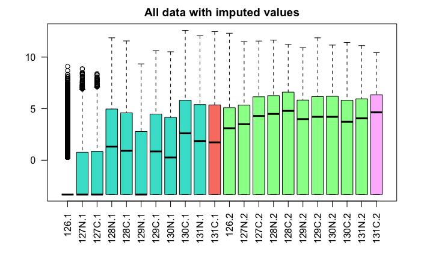

```r
res.miss.imp = melt(exprs(impute.res.all))
colnames(res.miss.imp) = c("Row","Dosage","Abundance_imp")
boxplot(log2(res.miss.imp$Abundance+0.1)~as.factor(res.miss.imp$Dosage),las=2,col=rep(c("turquoise", "salmon","palegreen","plum1"),times=c(10,1,10,1)),main="All data with imputed values")
```

```
NaNs produced
```

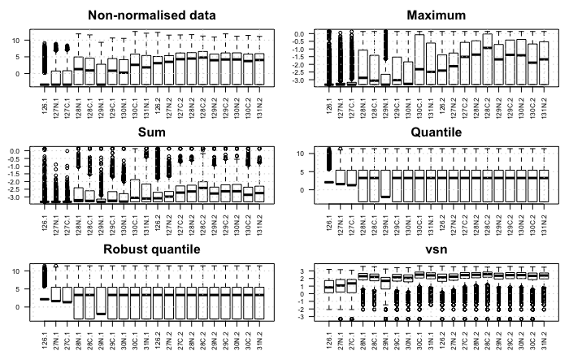

```r
oldmar <- par()$mar
par(mfrow=c(3,2),mar=c(2.9,2.9,2.9,1))
.plot(impute.res, ttl = "Non-normalised data")
.plot(qnt.max, ttl = "Maximum")
.plot(qnt.sum, ttl = "Sum")
.plot(qnt.quant, ttl = "Quantile")
.plot(qnt.qrob, ttl = "Robust quantile")
.plot(qnt.vsn, ttl = "vsn")
```

[output not shown]

Given the nature of the data, we will not be using any form of normalisation. We expect to see peaks and troughs across the fractions and normalisation will remove this information. Hence, we will keep it as is.

```
Combined 45620 features into 45620 using sum
Combined 41944 features into 41944 using median
```

```
[1] 691
```

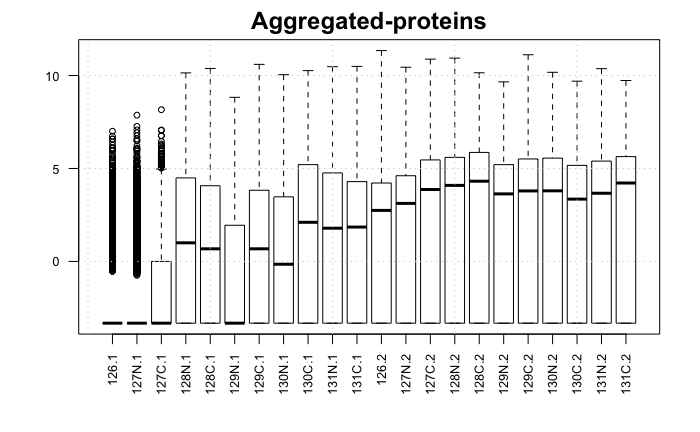

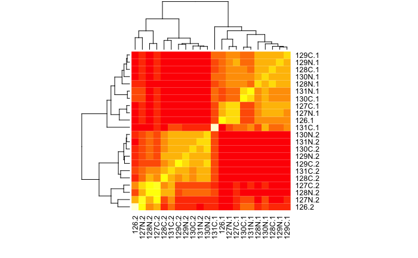

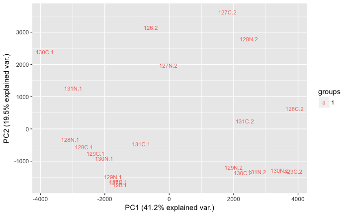

```r
#-------------------------------------------------------------------------------------------
# Function  : aggPep
# Aim       : Aggregate peptides into proteins, plots samples
# Input     : 'res' or any other MSnSet object which contains peptide abundances
# Output    : qnt.prot, another MSnSet object that contains proteins abundances
#-------------------------------------------------------------------------------------------
aggPep <- function(res,num.markers){

  pep.res<- fData(res)$Sequence
  prot.res<- fData(res)$Master.Protein.Accessions

  # Aggregating peptides into peptide groups
  qnt.pep<- combineFeatures(res, groupBy = pep.res, fun = "sum",cv.norm="none",cv=F)
  dim(qnt.pep) # 41944 peptide groups from 45620 peptides

  # Aggregating peptide abundance values into protein abundance values
  prot.res<- fData(qnt.pep)$Master.Protein.Accessions
  qnt.prot <- combineFeatures(qnt.pep, groupBy = prot.res, fun = "median")
  dim(qnt.prot) # 7074

  # How many proteins have cellular markers
  print(length(unique(intersect(fData(qnt.prot)$Master.Protein.Accessions,cell.markers$Protein))))

  # Basic plots of protein data across samples
  .plot(qnt.prot,ttl="Aggregated-proteins")
  #plot(hclust(dist(exprs(t(qnt.prot)))))

  # Looking at sample correlations
  cor.prot = cor(exprs(qnt.prot),use='complete.obs')
  heatmap(cor.prot,cex.main = 0.8)

  dissimilarity <- 1 - cor.prot
  distance <- as.dist(dissimilarity)
  #plot(hclust(distance))

  # Filter out rows that contains only 0s
  #zeroes = which(rowSums(is.na(exprs(qnt.prot))) == num.markers)
  #qnt.prot.nozero = qnt.prot[-zeroes,]
  #l = length(unique(intersect(fData(qnt.prot.nozero)$Master.Protein.Accessions,cell.markers$Protein)))
  #print(l)

  # Draw PCAs
  temp = exprs(qnt.prot)[which(rowSums(is.na(exprs(qnt.prot)))<20),]
  temp[is.na(temp)] = 0
  prot.pca = prcomp(t(temp))
  gp = strsplit(colnames(temp),"\\.")[[1]][2]
  j <- ggbiplot(prot.pca, var.axes=F, groups = gp, circle = T,obs.scale=1,labels=rownames(prot.pca$x))
  print(j)

  return(qnt.prot)
}
# ---------------------------------------------------------------------------------
# Step 06 : Aggregate peptide data to protein expression values
# There is an in-built function called 'combineFeatures' to do thi within MSnBase
# ---------------------------------------------------------------------------------
# Will try and aggregate values across all fractions as well as just in set1 and just in set2
res.all.prot = scale(aggPep(impute.res.all,22)) # All 20 fractions
```

```
Combined 45620 features into 45620 using sum
Combined 41944 features into 41944 using median
```

```
[1] 691
```

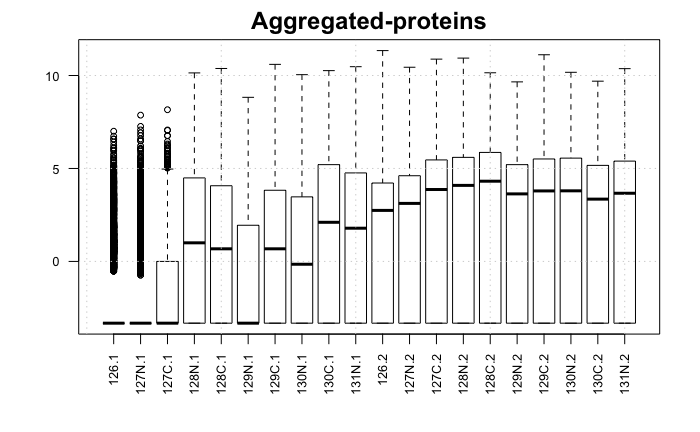

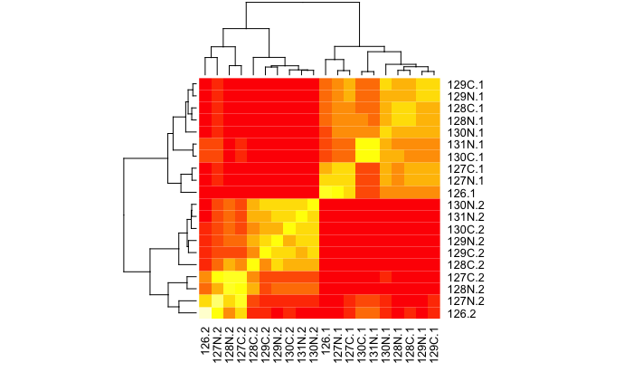

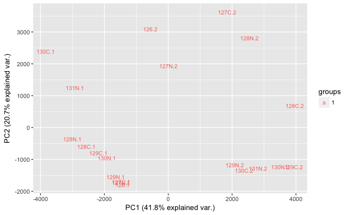

```r
res.prot = scale(aggPep(impute.res,20)) # All 20 fractions
```

```
Combined 45620 features into 45620 using sum
Combined 41944 features into 41944 using median
```

```
[1] 691
```

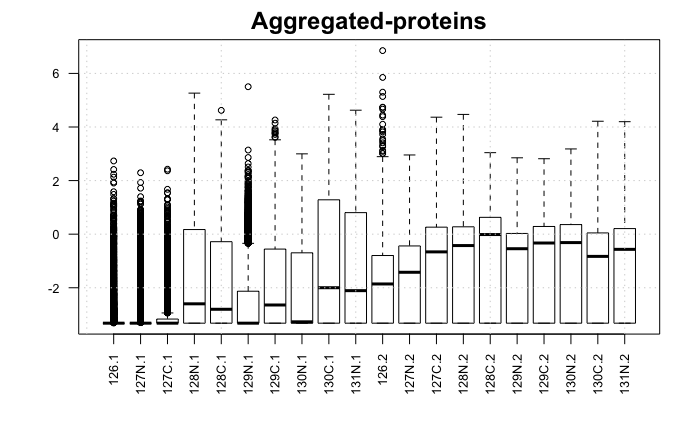

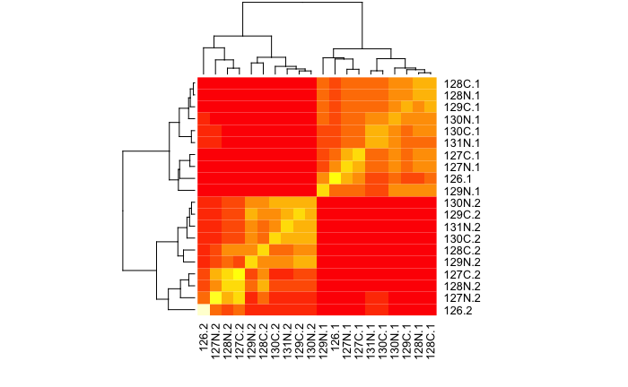

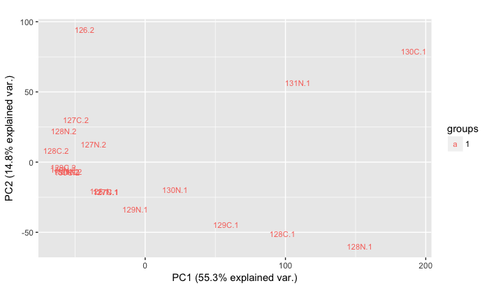

```r
res.norm.prot = scale(aggPep(impute.res.norm,20))
```

```
Combined 45620 features into 45620 using sum
Combined 41944 features into 41944 using median
```

```
[1] 691
```

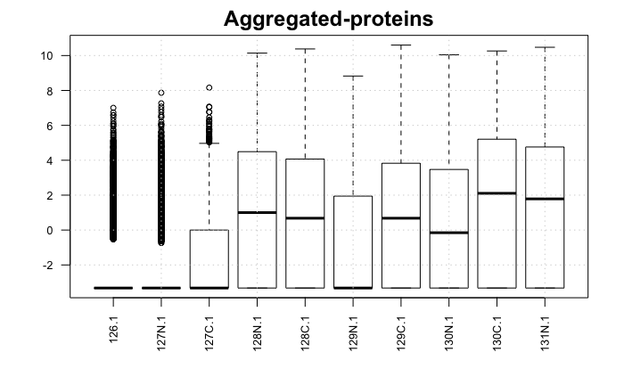

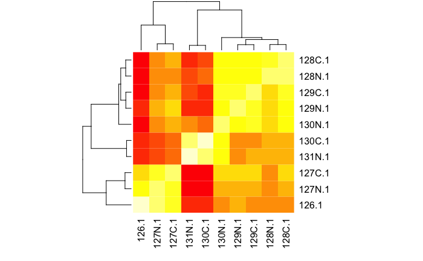

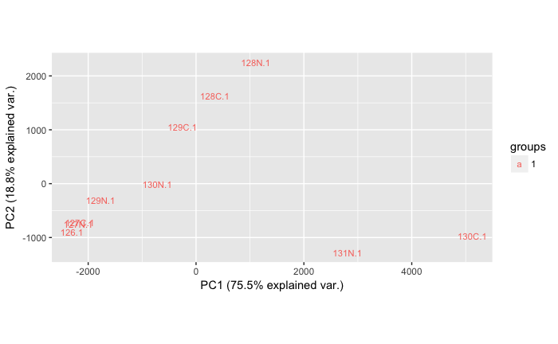

```r
set1.prot = aggPep(impute.set1,10) # Just 1-11
```